# aed

[figure not shown]

M2.878 · Trabajo de Fin de Máster · AED

2025-2 · Máster universitario en Ciencia de datos

Marcos Rodríguez Soler

# Análisis Exploratorio de Datos

En este *notebook* se lleva a cabo el **Análisis Exploratorio de los Datos** que se estructura en los siguientes subapartados.

1. 1. Integración de los datos  
   1.1. Importación de los datos  
   1.2. Unión de los datos
2. 2. Exploración del conjunto de datos  
   2.1. Inspección general del dataset  
   2.2. Análisis de calidad de los datos  
   2.2.1. Valores nulos  
   2.2.2. Análisis de rangos  
   2.2.3. Inconsistencias  
   2.2.4. Roturas de *stock*
3. 3. Análisis de las variables  
   3.1. Análisis de las variables auxiliares  
   3.1.1. *producto*  
   3.1.2. *idSecuencia*  
   3.1.3. *isPromo*  
   3.1.4. *bolOpen*  
   3.1.5. *bolHoliday*  
   3.1.6. *diasEntrePedidos*  
   3.1.7. *diasLeadtime*  
   3.1.8. *eurPrecioMedio*  
   3.2. Análisis de la variable objetivo  
   3.3. Análisis conjunto
4. 4. *Clustering*

```python
import holidays

import numpy as np
import pandas as pd
import seaborn as sns

import matplotlib
from matplotlib.lines import Line2D
from matplotlib import pyplot as plt
from matplotlib.colors import Normalize, Colormap, ListedColormap

from statsmodels.tsa.stattools import adfuller

from sklearn.manifold import TSNE
from sklearn.decomposition import PCA
from sklearn.cluster import KMeans
from sklearn.preprocessing import StandardScaler

from typing import Any, Set, Dict, List, Tuple
from collections import defaultdict

%matplotlib inline
```

# 1. Integración de los datos

En este apartado se integran los datos provenientes de los siguientes tres archivos *xlsx*:

1. *DatosCicloAprovisionamiento.xlsx* → Información acerca del ciclo de reposición de cada producto. Contiene los campos *producto*, referente al identificador de cada producto, *diasEntrePedidos*, días del ciclo de revisión de cada producto, y *diasLeadTime*, que es el tiempo de entrega correspondiente a cada ítem.
2. *DatosPrecioMedio.xlsx* → Datos referentes a los precios de cada ítem. Contiene los atributos *producto*, siendo el identificador de cada producto, y *eurPrecioMedio*, que es el promedio del precio de cada ítem.
3. *Datos.xlsx* → Este es el fichero principal de datos, y está compuesto por cuatro hojas distintas:
   - Hoja *Venta* → Información acerca de la demanda de cada producto. Incluye las variables *producto*, que identifica a cada ítem de forma únivoca, *idSecuencia*, que se corresponde con una fecha en formato *YYYYmmdd*, y *udsVenta*, que son el número de ventas de un producto concreto en una fecha determinada.
   - Hoja *Calendario* → Información relevante de las fechas del calendario. Contiene los atributos *idSecuencia*, que es referente a una fecha, *bolOpen*, que indica si la tienda se encontraba abierta en una fecha concreta, y *bolHoliday*, que denota si la fecha se corresponde a una festividad.
   - Hoja *Promociones* → Datos acerca de los períodos promocionales de cada producto. Incluye los campos *producto*, referente al identificador único de cada ítem, *idSecuenciaIni*, que es la fecha inicial de la promoción, y *idSecuenciaFin*, que se corresponde con la fecha del fin del período promocional.
   - Hoja *Stock* → Información del inventario disponible de cada producto para un conjunto de fechas. Contiene las variables *producto*, para identificar cada elemento a la venta, *idSecuencia*, que se corresponde con una fecha, y *udsStock*, referente a las unidades disponibles de un producto en una fecha concreta.

El objetivo de este apartado consiste en la integración de todos estos archivos y hojas en un solo conjunto de datos, donde cada fila debe representar la demanda de un producto concreto en una fecha concreta, agregando información adicional tanto del ítem como de la fecha. Consecuentemente, este proceso de integración se debe hacer respecto a la hoja *Venta* del archivo *Datos.xslx*, donde se deben ir uniendo los otros ficheros u hojas mediante operaciones del tipo **LEFT JOIN** de SQL para siempre tener constancia de las ventas de cada producto.

## 1.1. Importación de los datos

El primer paso para integrar todos los datos en un solo conjunto consiste en la importación individual de los archivos y hojas anteriormente mencionados. Para ello, se utiliza la función **importar_datos()** que se define a continuación. Este procedimiento se encarga de cargar de forma automática los tres archvos *xlsx* con los que se va a trabajar, es decir, *DatosCicloAprovisionamiento.xlsx*, *DatosPrecioMedio.xlsx*, y todas las hojas de *Datos.xlsx*. Asimismo, cabe destacar que para el correcto funcionamiento de la función, los datos deben almacenarse en una carpeta distinta a la que contiene este *notebook* pero que esté en la misma jerarquía.

├── DIRECTORIO_CON_LOS_DATOS  
└── DIRECTORIO_ACTUAL

```python
def importar_datos(ruta_archivo: str, nombre_hoja=0, primeras_filas=5) -> pd.DataFrame:
    """Importa una hoja de un archivo Excel concreto y muestra algunos datos básicos para garantizar que la
    importación se ha llevado a cabo existosamente.

    Argumentos:
        ruta_archivo: str -> Ruta del archivo Excel que se desea importar.
        nombre_hoja -> Nombre de la hoja del archivo que se desea importar. Por defecto es 0, lo cual implica
        que el fichero tan solo contiene una sola hoja.
        primeras_filas -> Número del total de primeras filas que se desea imprimir

    Devuelve:
        pd.DataFrame -> DataFrame de Pandas con los datos importados.
    """
    # Nombre del archivo
    nombre: str = ruta_archivo.split("/")[2]
    nombre_completo: str = (
        f"El archivo \"{nombre}\""
        if nombre_hoja == 0
        else f"La hoja \"{nombre_hoja}\" del archivo \"{nombre}\""
    )

    # Importación
    dataset: pd.DataFrame = pd.read_excel(ruta_archivo, sheet_name=nombre_hoja)

    # Dimensiones
    dim1, dim2 = dataset.shape
    print(f"{nombre_completo} contiene {dim1} instancias y {dim2} atributos")

    # Variables
    campos: List[str] = dataset.columns
    print(f"{nombre_completo} incluye las variables \"{', '.join(campos)}\"", "\n")

    # Tipos de datos de cada variable y porcentaje de valores nulos
    tipos_datos: List[str] = [dataset[campo].dtype for campo in campos]
    nulos: pd.Series = dataset.isna().mean() * 100
    for campo, nulo, tipo_dato in zip(campos, nulos, tipos_datos):
        print(f"La variable \"{campo}\" contiene un {nulo}% de valores nulos y es de tipo \"{tipo_dato}\"")

    # Primeros registros
    print("\n")
    print(f"Se muestran los primeros {primeras_filas} registros", "\n", dataset.head(primeras_filas))

    return dataset
```

Así pues, se procede con la carga de los datos del archivo *DatosCicloAprovisionamiento.xlsx*.

```python
# Archivo DatosCicloAprovisionamiento.xlsx
ruta_datos_ciclo: str = "../DATOS/DatosCicloAprovisionamiento.xlsx"
datos_ciclo: pd.DataFrame = importar_datos(ruta_datos_ciclo)
```

```
El archivo "DatosCicloAprovisionamiento.xlsx" contiene 1000 instancias y 3 atributos
El archivo "DatosCicloAprovisionamiento.xlsx" incluye las variables "producto, diasEntrePedidos, diasLeadtime"

La variable "producto" contiene un 0.0% de valores nulos y es de tipo "int64"
La variable "diasEntrePedidos" contiene un 0.0% de valores nulos y es de tipo "int64"
La variable "diasLeadtime" contiene un 0.0% de valores nulos y es de tipo "int64"


Se muestran los primeros 5 registros
    producto  diasEntrePedidos  diasLeadtime
0         1                14            15
1         2                14            15
2         3                14            15
3         4                14            15
4         5                14            15
```

Se prosigue con el archivo *DatosPrecioMedio.xlsx*.

```python
# Archivo DatosPrecioMedio.xlsx
ruta_datos_precio: str = "../DATOS/DatosPrecioMedio.xlsx"
datos_precio: pd.DataFrame = importar_datos(ruta_datos_precio)
```

```
El archivo "DatosPrecioMedio.xlsx" contiene 1000 instancias y 2 atributos
El archivo "DatosPrecioMedio.xlsx" incluye las variables "producto, eurPrecioMedio"

La variable "producto" contiene un 0.0% de valores nulos y es de tipo "int64"
La variable "eurPrecioMedio" contiene un 0.0% de valores nulos y es de tipo "float64"


Se muestran los primeros 5 registros
    producto  eurPrecioMedio
0         1       68.730000
1         2      148.330000
2         3      169.000000
3         4        0.604383
4         5        4.553314
```

Se continua con la hoja *Venta* del archivo *Datos.xlsx*.

```python
# Hoja Venta del archivo Datos.xlsx
ruta_datos: str = "../DATOS/Datos.xlsx"
nombre_hoja: str = "Venta"
datos_ventas: pd.DataFrame = importar_datos(ruta_datos, nombre_hoja=nombre_hoja)
```

```
La hoja "Venta" del archivo "Datos.xlsx" contiene 629391 instancias y 3 atributos
La hoja "Venta" del archivo "Datos.xlsx" incluye las variables "producto, idSecuencia, udsVenta"

La variable "producto" contiene un 0.0% de valores nulos y es de tipo "int64"
La variable "idSecuencia" contiene un 0.0% de valores nulos y es de tipo "int64"
La variable "udsVenta" contiene un 0.0% de valores nulos y es de tipo "int64"


Se muestran los primeros 5 registros
    producto  idSecuencia  udsVenta
0         1     20240322         4
1         1     20240323         2
2         1     20240324         0
3         1     20240325         7
4         1     20240326         7
```

Se sigue la importación de datos con la hoja *Calendario* del archivo *Datos.xlsx*.

```python
# Hoja Calendario del archivo Datos.xlsx
nombre_hoja: str = "Calendario"
datos_calendario: pd.DataFrame = importar_datos(ruta_datos, nombre_hoja=nombre_hoja)
```

```
La hoja "Calendario" del archivo "Datos.xlsx" contiene 787 instancias y 3 atributos
La hoja "Calendario" del archivo "Datos.xlsx" incluye las variables "idSecuencia, bolOpen, bolHoliday"

La variable "idSecuencia" contiene un 0.0% de valores nulos y es de tipo "int64"
La variable "bolOpen" contiene un 0.0% de valores nulos y es de tipo "int64"
La variable "bolHoliday" contiene un 0.0% de valores nulos y es de tipo "int64"


Se muestran los primeros 5 registros
    idSecuencia  bolOpen  bolHoliday
0     20260518        1           0
1     20260517        1           0
2     20260516        1           0
3     20260515        1           0
4     20260514        1           0
```

Se prosigue con la hoja *Promociones* del archivo *Datos.xlsx*.

```python
# Hoja Calendario del archivo Datos.xlsx
nombre_hoja: str = "Promociones"
datos_promociones: pd.DataFrame = importar_datos(ruta_datos, nombre_hoja=nombre_hoja)
```

```
La hoja "Promociones" del archivo "Datos.xlsx" contiene 26511 instancias y 3 atributos
La hoja "Promociones" del archivo "Datos.xlsx" incluye las variables "producto, idSecuenciaIni, idSecuenciaFin"

La variable "producto" contiene un 0.0% de valores nulos y es de tipo "int64"
La variable "idSecuenciaIni" contiene un 0.0% de valores nulos y es de tipo "int64"
La variable "idSecuenciaFin" contiene un 0.0% de valores nulos y es de tipo "int64"


Se muestran los primeros 5 registros
    producto  idSecuenciaIni  idSecuenciaFin
0       570        20121122        20130111
1        48        20200511        20200611
2       120        20140116        20140321
3       936        20170316        20170416
4       249        20260317        20260406
```

Por último, se terminan las importaciones con la hoja *Stock* del archivo *Datos.xlsx*.

```python
# Hoja Stock del archivo Datos.xlsx
nombre_hoja: str = "Stock"
datos_stock: pd.DataFrame = importar_datos(ruta_datos, nombre_hoja=nombre_hoja)
```

```
La hoja "Stock" del archivo "Datos.xlsx" contiene 629391 instancias y 3 atributos
La hoja "Stock" del archivo "Datos.xlsx" incluye las variables "producto, idSecuencia, udsStock"

La variable "producto" contiene un 0.0% de valores nulos y es de tipo "int64"
La variable "idSecuencia" contiene un 0.0% de valores nulos y es de tipo "int64"
La variable "udsStock" contiene un 0.0% de valores nulos y es de tipo "int64"


Se muestran los primeros 5 registros
    producto  idSecuencia  udsStock
0         1     20240323       126
1         1     20240324       125
2         1     20240325       217
3         1     20240326       210
4         1     20240327       203
```

Las importaciones han tenido lugar de forma existosa, ya que tanto las dimensiones de los conjuntos, como los atributos y los tipos de cada variable se corresponden con los contenidos de las mismas hojas y archivos *xlsx*. Asimismo, no se han encontrado valores nulos en ningún conjunto de datos de manera que, por el momento, facilita el proceso de integración. Adicionalmente, cabe destacar el hecho que las variables referentes a fechas se han codificado a tipo *int64* a pesar de que representan una fecha. Esto ahora mismo no supone un problema ya que estos campos se usarán como clave para cruzar los distintos conjuntos de datos extraídos.

## 1.2. Unión de los datos

Una vez se han extraído los contenidos de las hojas y archivos *xlsx*, se procede con la unión de los distintos conjuntos empleando como referencia la hoja *Venta* del archivo *Datos.xlsx* ya que, como se mencionó anteriormente, esta hoja es la que contiene la información más importante para predecir la demanda futura, siendo la propia demanda que tuvo lugar en el pasado. Sin embargo, antes de fusionar los conjuntos se debe tener presente que la unión con la hoja *Promociones* no es trivial, dado que no existe un atributo que sirva de punto de unión entre ambas tablas. Así pues, la unión se debe hacer en este caso mediante una máscara *booleana* que se pasa al *dataset* de ventas, donde se filtran aquellas filas cuya ID del producto se corresponda con un ítem sujeto a promoción, basándose en el período promocional que comprende el intervalo que va desde *idSecuenciaIni* hasta *idSecuenciaFin*, donde ambos campos pertenece a la hoja *Promociones*. Esto da lugar a la variable *isPromo* que denota si un producto concreto en una fecha determinada estaba sujeto a promoción.

```python
# Adición de la variable isPromo
for _, fila in datos_promociones.iterrows():
    id_producto: int = fila["producto"]
    fecha_inicial: int = fila["idSecuenciaIni"]
    fecha_final: int = fila["idSecuenciaFin"]

    condicion: pd.Series = (
        (datos_ventas["producto"] == id_producto) &
        (datos_ventas["idSecuencia"] >= fecha_inicial) &
        (datos_ventas["idSecuencia"] <= fecha_final)
    )

    datos_ventas.loc[condicion, "isPromo"] = 1

datos_ventas["isPromo"] = datos_ventas["isPromo"].fillna(0).astype(int)
```

Tras haber plasmado la información de la hoja *Promociones* en el conjunto de datos *datos_ventas*, se termina con la unión con las otras hojas y archivos.

```python
# Unión con la hoja Calendario
dataset_temporal_1: pd.DataFrame = datos_ventas.merge(
    datos_calendario,
    how="left",
    left_on="idSecuencia",
    right_on="idSecuencia"
)

# Unión con la hoja Stock
dataset_temporal_2: pd.DataFrame = dataset_temporal_1.merge(
    datos_stock,
    how="left",
    left_on=["producto", "idSecuencia"],
    right_on=["producto", "idSecuencia"]
)

# Unión con el archivo DatosCicloAprovisionamiento.xlsx
dataset_temporal_3: pd.DataFrame = dataset_temporal_2.merge(
    datos_ciclo,
    how="left",
    left_on="producto",
    right_on="producto"
)

# Unión con el archivo DatosPrecioMedio.xlsx
dataset: pd.DataFrame = dataset_temporal_3.merge(
    datos_precio,
    how="left",
    left_on="producto",
    right_on="producto"
)
```

# 2. Exploración de los datos

Una vez se han integrado los datos en un conjunto global ya se dispone de suficiente información para iniciar formalmente la etapa del análisis exploratorio.

## 2.1. Inspección general del *dataset*

Esta sección sirve para adquirir una noción fundamental de la estructura del *dataset* global tras la unión de las distintas hoja y archivos del apartado anterior. El contexto de los datos se sitúa en una empresa de productos de distribución para el automóvil, donde los datos de los productos se han anonimizado por motivos de confidencialidad.

```python
# Información básica del conjunto de datos global
dataset.info()
```

```
<class 'pandas.DataFrame'>
RangeIndex: 629391 entries, 0 to 629390
Data columns (total 10 columns):
 #   Column            Non-Null Count   Dtype
---  ------            --------------   -----
 0   producto          629391 non-null  int64
 1   idSecuencia       629391 non-null  int64
 2   udsVenta          629391 non-null  int64
 3   isPromo           629391 non-null  int64
 4   bolOpen           628530 non-null  float64
 5   bolHoliday        628530 non-null  float64
 6   udsStock          628530 non-null  float64
 7   diasEntrePedidos  629391 non-null  int64
 8   diasLeadtime      629391 non-null  int64
 9   eurPrecioMedio    629391 non-null  float64
dtypes: float64(4), int64(6)
memory usage: 48.0 MB
```

```python
# Primeras 5 filas del dataset global
dataset.head()
```

|  | producto | idSecuencia | udsVenta | isPromo | bolOpen | bolHoliday | udsStock | diasEntrePedidos | diasLeadtime | eurPrecioMedio |
| --- | --- | --- | --- | --- | --- | --- | --- | --- | --- | --- |
| 0 | 1 | 20240322 | 4 | 0 | NaN | NaN | NaN | 14 | 15 | 68.73 |
| 1 | 1 | 20240323 | 2 | 0 | 1.0 | 0.0 | 126.0 | 14 | 15 | 68.73 |
| 2 | 1 | 20240324 | 0 | 0 | 0.0 | 1.0 | 125.0 | 14 | 15 | 68.73 |
| 3 | 1 | 20240325 | 7 | 0 | 1.0 | 0.0 | 217.0 | 14 | 15 | 68.73 |
| 4 | 1 | 20240326 | 7 | 0 | 1.0 | 0.0 | 210.0 | 14 | 15 | 68.73 |

```python
# Se comprueba que no existen registros duplicados
if not all(dataset[["producto", "idSecuencia"]].duplicated()):
    print("El conjunto de datos no contiene ninguna muestra duplicada")
```

```
El conjunto de datos no contiene ninguna muestra duplicada
```

El conjunto de datos ahora cuenta con 10 variables distintas. Asimismo, el número total de registros se sigue manteniendo constante respecto al *dataset* de nombre *datos_ventas*, dado que las uniones se han hecho respecto a esta misma tabla. Por otro lado, cabe destacar que ahora sí aparecen valores faltantes en los datos, ya que es lo que ocurre cuando se unen dos *DataFrames* con un **LEFT JOIN** y no se encuentran coincidencias entre la tabla de la izquierda y la de la derecha, resultando en valores nulos en los atributos del conjunto de la derecha. En este contexto, se ofrece una descripción breve de los campos que conforman el nuevo conjunto de datos global. Asimismo, es importante destacar el hecho que cada fila representa la demanda de un producto en una fecha concreta, y que el *dataset* se estructura a nivel producto-día.

- *producto* → Identificador único de cada ítem del negocio
- *idSecuencia* → Fecha en formato entero de la que se dispone de la demanda de un producto concreto
- *udsVenta* → Demanda de un producto a lo largo de una fecha concreta
- *isPromo* → Indica si el ítem a la venta formaba parte de una promoción en una fecha concreta
- *bolOpen* → Denota si la tienda del negocio estaba abierta en una fecha concreta
- *bolHoliday* → Indica si una fecha concreta formaba parte de un período vacacional
- *udsStock* → Número de unidades en el almacén de un producto concreto en una fecha determinada
- *diasEntrePedidos* → Intervalo de tiempo en días que debe pasar para realizar pedidos de un producto concreto
- *diasLeadtime* → Tiempo de entrega en días de un ítem determinado
- *eurPrecioMedio* → Promedio del precio de un producto

Es muy importante comentar el hecho que la variable *udsStock* no se puede emplear en los modelos predictivos, ya que contiene información que no es conocida a futuro y que, por lo tanto, no puede usarse para realizar predicciones. No obstante, aporta información útil para comprender algunos fenómenos que se dan en el *dataset* como se mostrará más adelante.

Por último, se realiza un breve análisis estadístico descriptivo de las variables numéricas del conjunto de datos.

```python
# Resumen estadístico de las variables numéricas del dataset
dataset[["udsVenta", "udsStock", "eurPrecioMedio", "diasLeadtime", "diasEntrePedidos"]].describe().round(2).T
```

|  | count | mean | std | min | 25% | 50% | 75% | max |
| --- | --- | --- | --- | --- | --- | --- | --- | --- |
| udsVenta | 629391.0 | 1.19 | 2.22 | 0.00 | 0.00 | 0.00 | 2.00 | 397.00 |
| udsStock | 628530.0 | 44.59 | 33.59 | 0.00 | 27.00 | 39.00 | 55.00 | 717.00 |
| eurPrecioMedio | 629391.0 | 50.60 | 67.86 | 0.01 | 8.57 | 26.71 | 62.92 | 625.26 |
| diasLeadtime | 629391.0 | 5.48 | 5.25 | 1.00 | 2.00 | 4.00 | 4.00 | 22.00 |
| diasEntrePedidos | 629391.0 | 13.73 | 2.52 | 1.00 | 14.00 | 14.00 | 14.00 | 34.00 |

A partir de los estadísticos descriptivos de las variables numéricas se pueden extraer varias conclusiones relevantes. En primer lugar, la variable *udsVenta* presenta una distribución altamente asimétrica, tal y como se observa por la diferencia entre la media y la mediana, así como por la presencia de valores máximos muy elevados de hasta 397 unidades. Esto indica que la demanda se caracteriza por una gran cantidad de días con ventas nulas o muy bajas, como se observó en el apartado Roturas de *stock*, combinados con picos puntuales de alta demanda. En cuanto a la variable *eurPrecioMedio*, se observa una elevada dispersión, lo que refleja una considerable heterogeneidad en el catálogo de productos, con artículos de bajo coste y otros significativamente más caros. Por otro lado, las variables *diasLeadtime* y *diasEntrePedidos* presentan una variabilidad más contenida, lo que sugiere una mayor estabilidad en los procesos logísticos. En particular, *diasEntrePedidos* muestra una concentración clara entorno a 14 días, indicando un patrón de reposición bastante regular para la mayoría de productos.

Por otro lado, se crea la variable *fecha* que representa el mismo concepto que *idSecuencia* pero está codificada a un tipo de dato *datetime* de *Pandas*, lo cual resulta útil para generar gráficos para comprender los horizontes de la demanda que cubre el *dataset*.

```python
# Campo fecha
dataset["fecha"] = pd.to_datetime(dataset["idSecuencia"], format="%Y%m%d")
```

### 2.2.1. Valores nulos

Uno de los aspectos más importantes a tener en cuenta durante la exploración de los datos es la detección de anomalías, en este caso referiéndose a la presencia de valores nulos. A pesar de que los conjuntos individuales que se trataron en el apartado Importación de los datos no presentaban valores faltantes, la unión entre ellos con la operación **LEFT JOIN** sí que da origen a estas valores si no se encuentran correspondencias entre los juegos de datos que se asocian. En este sentido, es importante tener presente el porcentaje de nulos por variable, su valor absoluto por atributo, y los patrones de valores ausentes por fila.

```python
print("Proporción de nulos por variable\n", dataset.isna().mean() * 100, "\n")
print("Total de nulos por variable\n", dataset.isna().sum())
```

```
Proporción de nulos por variable
 producto            0.000000
idSecuencia         0.000000
udsVenta            0.000000
isPromo             0.000000
bolOpen             0.136799
bolHoliday          0.136799
udsStock            0.136799
diasEntrePedidos    0.000000
diasLeadtime        0.000000
eurPrecioMedio      0.000000
fecha               0.000000
dtype: float64

Total de nulos por variable
 producto              0
idSecuencia           0
udsVenta              0
isPromo               0
bolOpen             861
bolHoliday          861
udsStock            861
diasEntrePedidos      0
diasLeadtime          0
eurPrecioMedio        0
fecha                 0
dtype: int64
```

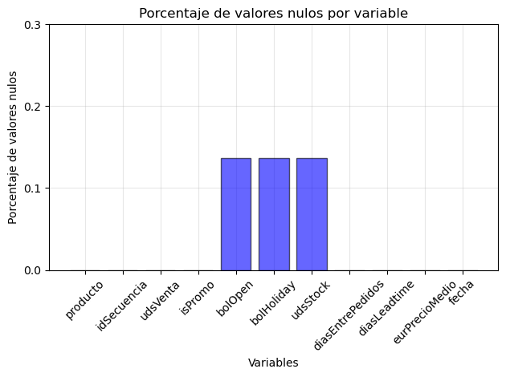

```python
# Gráfico de barras con los porcentajes de valores nulos por variable
plt.bar(dataset.isna().mean().index.tolist(), dataset.isna().mean() * 100, color="blue", alpha=0.6, edgecolor="black", linewidth=1)

plt.title("Porcentaje de valores nulos por variable")
plt.xlabel("Variables")
plt.tick_params(axis="x", rotation=45)
plt.ylabel("Porcentaje de valores nulos")
plt.yticks([i/10 for i in range(0, 4, 1)])

plt.grid(True, alpha=0.3)
plt.gca().set_axisbelow(True)

plt.tight_layout()
plt.show()
```

```python
# Patrones de nulos por fila
patrones: Dict[str, int] = defaultdict(int)
for _, fila in dataset.iterrows():

    estado_apertura: str = "1" if np.isnan(fila["bolOpen"]) else "0"
    estado_vacaciones: str = "1" if np.isnan(fila["bolHoliday"]) else "0"
    estado_inventario: str = "1" if np.isnan(fila["udsStock"]) else "0"
    patron_nulos: str = estado_apertura + estado_vacaciones + estado_inventario

    patrones[patron_nulos] += 1

print("Patrones de valores nulos por fila:\n")
for clave, valor in patrones.items():
    print(f"{clave} filas con el patrón {valor}")
```

```
Patrones de valores nulos por fila:

111 filas con el patrón 861
000 filas con el patrón 628530
```

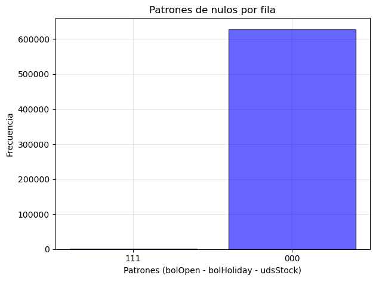

```python
plt.bar(patrones.keys(), patrones.values(), color="blue", alpha=0.6, edgecolor="black", linewidth=1)

plt.title("Patrones de nulos por fila")
plt.xlabel("Patrones (bolOpen - bolHoliday - udsStock)")
plt.ylabel("Frecuencia")

plt.grid(True, alpha=0.3)
plt.gca().set_axisbelow(True)

plt.tight_layout()
plt.show()
```

Las columnas *bolOpen*, *bolHoliday*, y *udsStock* son las únicas que contienen estos valores, además en la misma proporción. Asimismo, existe un único patrón de valores nulos por fila en todo el conjunto de datos, que es cuando las tres variables mencionadas anteriormente contienen valores ausentes simultáneamente en la misma fila. Esto apunta a que la aparición de estos valores está fuertemente relacionada con la estructura de las dos tablas que se han unido en el apartado Unión de los datos, siendo estas la hoja *Ventas* del archivo *Datos.xlsx* y la hoja *Calendario* del mismo archivo. Dado que ambos conjuntos de datos se han unido a través del campo *idSecuencia*, este hecho indica que hay fechas de la demanda histórica de las que no se dispone de la información de *bolOpen* y *bolHoliday*. De forma parecida, la unión de la hoja *Ventas* con la hoja *Stock* del propio fichero *Datos.xlsx* se realizó empleando los atributos *producto* e *idSecuencia* como punto de unión, de manera que también existen fechas de las que no se dispone del inventario en aquel momento.

```python
# Fechas asociadas a las filas con nulos
na_dataset: pd.DataFrame = dataset.loc[dataset.isna().any(axis=1)]
fechas_con_nulos: pd.Series = na_dataset["idSecuencia"].unique()

print("Las fechas asociadas a las filas con valores nulos son:\n")
for fecha in fechas_con_nulos:
    print(fecha)
```

```
Las fechas asociadas a las filas con valores nulos son:

20240322
```

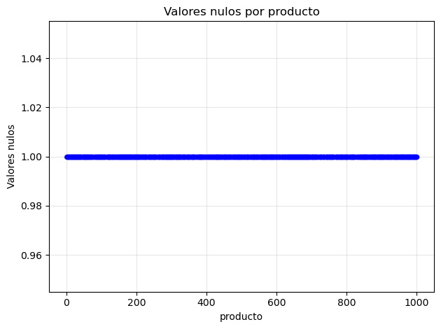

```python
# Nulos por producto
nulos_producto: pd.DataFrame = dataset.groupby("producto", as_index=False).agg(
    total_nulos=(
        "bolOpen",
        lambda g: g.isna().sum()
    )
)

ax: matplotlib.axes.Axes = nulos_producto.plot(
    kind="scatter",
    x="producto",
    y="total_nulos",
    color="blue",
    alpha=0.6
)

ax.set_title("Valores nulos por producto")
ax.set_xlabel("producto")
ax.set_ylabel("Valores nulos")

ax.grid(True, alpha=0.3)
ax.set_axisbelow(True)

plt.tight_layout()
plt.show()
```

El hecho de que el día 2024-03-22 sea la única fecha de la que no se dispone de *bolOpen*, *bolHoliday* y *udsStock* denota que existe un problema con la fuente de datos, donde quizás se olvidó añadir los registros de las variables destacadas para esta fecha concreta.

Así pues, tras entender tanto los valores nulos del conjunto de datos como su origen, se decide eliminar todos los registros del *dataset* con este tipo de datos. Se considera que el impacto negativo que esto tiene es mínimo, ya que tan solo se está eliminando una fecha por producto y los intervalos de la demanda histórica abarcan mucho más tiempo. Asimismo, el origen de estos datos no es aleatorio y está relacionado con la propia fuente de los estos. Por otro lado, estos valores aparecen en variables importantes que se utilizarán más adelante en el proceso de modelado y, además, se considera que un proceso de imputación sería excesivamente complejo para el impacto despreciable que tendría, donde posiblemente se terminara añadiendo una pequeña fuente de sesgo en los datos.

```python
# Eliminación de filas con nulos
dataset.dropna(inplace=True)
```

### 2.2.2 Análisis de rangos

Otro indicador de la calidad de los datos son los rangos numéricos que estos abarcan. Estos intervalos deben comprender un conjunto de valores que sea coherente con la naturaleza de cada variable ya que, por ejemplo, resularía ilógico encontrar un valor negativo de la variable *eurPrecioMedio*. Para analizar esta característica de los datos, resulta especialmente útil la visualización tanto de los histogramas como de los *boxplots* de cada atributo.

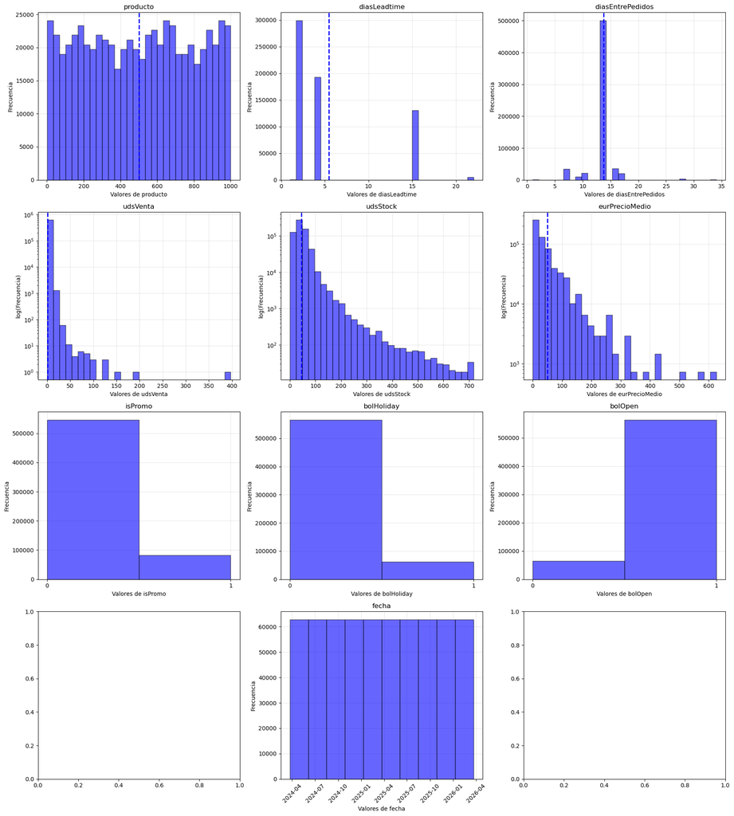

```python
# Histogramas de las variables del dataset
vars: List[str] = [
    "producto", "diasLeadtime", "diasEntrePedidos", "udsVenta", "udsStock", "eurPrecioMedio",
    "isPromo", "bolHoliday", "bolOpen", "", "fecha"
]

fig, axs = plt.subplots(nrows=4, ncols=3, figsize=(18, 20))
axs = axs.flatten()

for i, (ax, var) in enumerate(zip(axs, vars)):
    if i == 9:
        continue

    if var in ["producto", "diasEntrePedidos", "diasLeadtime"]:
        dataset[var].hist(ax=ax, bins=30, alpha=0.6, edgecolor="black", linewidth=1, color="blue")
        frecuencia: str = "Frecuencia"
        ax.axvline(dataset[var].mean(), color="blue", linestyle="--", linewidth=2)
    elif var == "fecha":
        dataset[var].hist(ax=ax, alpha=0.6, edgecolor="black", linewidth=1, color="blue")
        frecuencia: str = "Frecuencia"
        ax.tick_params("x", rotation=45)
    elif var in ["isPromo", "bolOpen", "bolHoliday"]:
        dataset[var].hist(ax=ax, bins=2, alpha=0.6, edgecolor="black", linewidth=1, color="blue")
        frecuencia: str = "Frecuencia"
        ax.set_xticks([0, 1])
    else:
        dataset[var].hist(ax=ax, log=True, bins=30, alpha=0.6, edgecolor="black", linewidth=1, color="blue")
        frecuencia: str = "log(Frecuencia)"
        ax.axvline(dataset[var].mean(), color="blue", linestyle="--", linewidth=2)

    ax.set_title(f"{var}")
    ax.set_xlabel(f"Valores de {var}")
    ax.set_ylabel(frecuencia)

    ax.grid(True, alpha=0.3)
    ax.set_axisbelow(True)

plt.tight_layout()
plt.show()
```

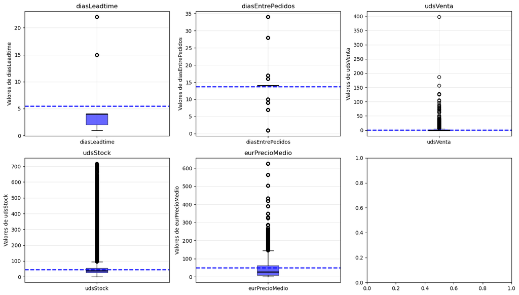

```python
# Boxplots de las variables numéricas
num_vars: List[str] = ["diasLeadtime", "diasEntrePedidos", "udsVenta", "udsStock", "eurPrecioMedio"]

fig, axs = plt.subplots(nrows=2, ncols=3, figsize=(14, 8))
axs = axs.flatten()

for ax, num_var in zip(axs, num_vars):
    dataset[num_var].plot(
        kind="box",
        ax=ax,
        patch_artist=True,
        boxprops=dict(facecolor="blue", alpha=0.6, color="black", linewidth=1),
        medianprops=dict(color="black", linewidth=2),
        whiskerprops=dict(color="black", linewidth=1),
        capprops=dict(color="black", linewidth=1)
    )

    ax.axhline(dataset[num_var].mean(), color="blue", linestyle="--", linewidth=2)

    ax.set_title(num_var)
    ax.set_ylabel(f"Valores de {num_var}")

    ax.grid(True, alpha=0.3)
    ax.set_axisbelow(True)

plt.tight_layout()
plt.show()
```

Los gráficos representados permiten comprobar que las variables numéricas del conjunto de datos presentan valores coherentes con su interpretación, sin evidencias de errores como valores negativos o incoherentes. No obstante, en algunas de estas variables se observan valores extremos, especialmente en aquellas relacionadas con los niveles de inventario y el precio. Estos valores no se consideran errores, sino que reflejan comportamientos reales del negocio, como picos de demanda en determinados productos o artículos con precios significativamente más elevados que la media. Por este motivo, no se contempla la posibilidad de aplicar ningún tratamiento específico sobre estos valores, ya que su eliminación podría suponer la pérdida de información relevante para el entrenamiento de los modelos de predicción.

Por otro lado, las proporciones de las dos categorías de las variables binarias *isPromo*, *bolOpen* y *bolHoliday* son coherentes con la naturaleza de los propios atributos. En este caso, en la mayoría de los días del *dataset* los artículos no se someten a una promoción, la gran mayoría de fechas no se corresponden con días festivos, y el establecimiento abrió sus puertas durante gran parte de los días del conjunto de datos.

Finalmente, la distribución de horizontes de la demanda es muy uniforme y, teniendo en cuenta que la demanda se ofrece para cada producto y una vez al día, indica que los intervalos de las series temporales de la demanda de cada ítem son homogéneos. Asimismo, este periodo abarca dos años, desde marzo del 2024 hasta el mismo mes del año 2026. No obstante, esto entra en conflicto con lo observado en el histograma de la variable *producto*, de manera que se considera la posibilidad de que el *dataset* no incluya la información de los 1000 productos. Esto se profundizará en el apartado *producto* del **Análisis Estadístico** de las variables.

### 2.2.3 Inconsistencias

El conjunto de datos global del que se dispone contiene las variables *udsVenta* y *udsStock*, las cuales registran las ventas de un producto en un día concreto, y el volumen de unidades de un ítem concreto en una fecha determinada. El objetivo de esta sección es analizar aquellos casos donde el número de ventas en un día supera el inventario disponible, hecho que es imposible, así como tratar de entender el origen potencial de este fenómeno en el *dataset*. Para ello, se analizan las inconsistencias a nivel general y a nivel de producto.

```python
# Inconsistencias
inconsistencias: int = dataset[dataset["udsVenta"] > dataset["udsStock"]].shape[0]
print(f"Existen {inconsistencias} casos donde se vendieron más unidades que stock disponible")
```

```
Existen 1621 casos donde se vendieron más unidades que stock disponible
```

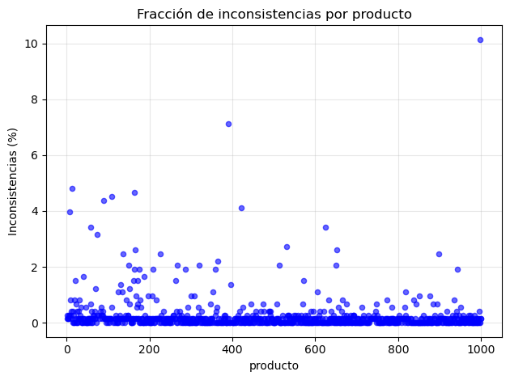

```python
# Inconsistencias por producto
inconsistencias_producto: pd.Series = dataset.groupby("producto", as_index=False).apply(
    lambda g: (g["udsVenta"] > g["udsStock"]).mean() * 100
)
inconsistencias_producto.columns = ["producto", "inconsistencias"]

ax: matplotlib.axes.Axes = inconsistencias_producto.plot(
    kind="scatter",
    x="producto",
    y="inconsistencias",
    alpha=0.6,
    color="blue"
)

ax.set_title("Fracción de inconsistencias por producto")
ax.set_xlabel("producto")
ax.set_ylabel("Inconsistencias (%)")

ax.grid(True, alpha=0.3)
ax.set_axisbelow(True)

plt.tight_layout()
plt.show()
```

```python
# Los 5 productos con mayor proporción de anomalías
inconsistencias_producto.sort_values(by="inconsistencias", ascending=False).head()
```

|  | producto | inconsistencias |
| --- | --- | --- |
| 858 | 998 | 10.136986 |
| 338 | 391 | 7.123288 |
| 11 | 13 | 4.794521 |
| 142 | 163 | 4.657534 |
| 97 | 110 | 4.520548 |

A pesar de que los 1621 casos de inconsistencias suponen una fracción muy reducida del conjunto de datos global, esta observación plantea una cuestión aún más importante, ya que la fuente de las anomalías bien puede ser la variable objetivo *udsVentas* o el atributo auxiliar *udsStock*, o incluso ambas. Para ello, es importante revisar las ventas e inventarios de algunos de los productos con mayor proporción de anomalías.

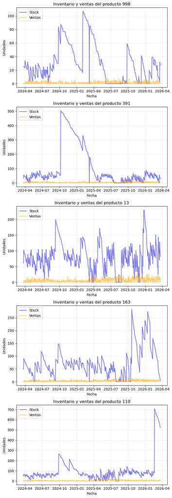

```python
productos: List[int] = (
    inconsistencias_producto
    .sort_values(by="inconsistencias", ascending=False)["producto"]
    .tolist()[:5]
)
fig, axs = plt.subplots(nrows=len(productos), ncols=1, figsize=(7, 20))

for ax, producto in zip(axs, productos):
    dataframe_producto: pd.DataFrame = dataset[dataset["producto"] == producto].copy()

    ax.plot(dataframe_producto["fecha"], dataframe_producto["udsStock"], label="Stock", color="blue", alpha=0.6)
    ax.plot(dataframe_producto["fecha"], dataframe_producto["udsVenta"], label="Ventas", color="orange", alpha=0.6)

    ax.set_title(f"Inventario y ventas del producto {producto}")
    ax.set_xlabel("Fecha")
    ax.set_ylabel("Unidades")
    ax.legend(loc="upper left")
    ax.grid(True, alpha=0.3)
    ax.set_axisbelow(True)

plt.tight_layout()
plt.show()
```

Tal y como se observa en los gráficos del inventario disponible frente a la demanda, existen muchos casos en los que el *stock* permanece en valores nulos durante periodos prolongados mientras se registran ventas de forma continuada y uniforme respecto a otros tramos del intervalo. Además, la caída del inventario a 0 en varias ocasiones no se produce paulatinamente, sino de forma abrupta. Adicionalmente, se identifican variaciones en el inventario no explicadas por las ventas, lo que apunta a la existencia de ajustes no observados en el sistema. En un contexto real, estos fenómenos pueden deberse a descartes por controles de calidad periódicos, fechas de caducidad, o accidentes, pero las caídas bruscas del *stock* en muchos casos resultan complicadas de explicar por estos hechos de los que no se tiene información, por lo que se considera que se dispone de evidencia suficiente para situar el origen de las inconsistencias en *udsStock* en lugar de *udsVenta*. Asimismo, estas anomalías pueden estar ocurriendo debido a que la variable *stock* puede no estar siendo correctamente actualizada en determinados periodos.

En conjunto, estos resultados indican que las inconsistencias detectadas se deben principalmente a limitaciones en la calidad de la variable de inventario, y no a errores en la variable de ventas. Este hecho no supone un problema de cara a la fase de modelado, ya que este atributo no se de debe añadir en los *datasets* que se usarán para entrenar a los modelos. Consecuentemente, las filas con inconsistencias se mantendrán en el conjunto de datos global ya que se concluye que la fuente de anomalías no es la variable objetivo sino un atributo que no se usará como *input* en los modelos.

### 2.2.4 Roturas de *stock*

Dentro del contexto de la previsión de la demanda, uno de los puntos más importantes que se deben tener en cuenta respecto al conjunto de datos que se utilizará para entrenar los modelos gira alrededor de las roturas de *stock*. Este fenómeno se produce cuando no se dispone de suficiente inventario para satisfacer la demanda en una fecha concreta. Este hecho es muy importante a considerar ya que, como bien se ha explicado anteriormente, la variable *udsStock* no se utilizará como entrada en los modelos predictivos. Consecuentemente, los modelos únicamente tendrán constancia de *udsVenta*, por lo que no podrán saber si los ceros en esta variable son porque la demanda es baja o porque se ha producido una rotura de *stock*. Asimismo, en este último caso el valor de *udsVenta* no refleja la demanda real ya que, por ejemplo, de haber dispuesto de suficiente inventario se hubieran vendido *n* unidades de un producto concreto.

```python
# Casos de demanda baja
demanda_baja: int = dataset[(dataset["udsVenta"] == 0) & (dataset["udsStock"] > 0)].shape[0]
print(f"En {demanda_baja} casos la demanda fue baja")
```

```
En 397730 casos la demanda fue baja
```

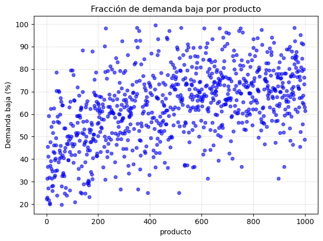

```python
# Casos de demanda baja por producto
demanda_baja_producto: pd.Series = dataset.groupby("producto", as_index=False).apply(
    lambda g: ((g["udsVenta"] == 0) & (g["udsStock"] > 0)).mean() * 100
)
demanda_baja_producto.columns = ["producto", "demanda_baja"]

ax: matplotlib.axes.Axes = demanda_baja_producto.plot(
    kind="scatter",
    x="producto",
    y="demanda_baja",
    alpha=0.6,
    color="blue"
)

ax.set_title("Fracción de demanda baja por producto")
ax.set_xlabel("producto")
ax.set_ylabel("Demanda baja (%)")

ax.grid(True, alpha=0.3)
ax.set_axisbelow(True)

plt.tight_layout()
plt.show()
```

En cualquier empresa es de esperar que la demanda de todos los productos no será la misma, donde un pequeño porcentaje de ítems presentará una demanda muy alta y la gran mayoría de productos tendrán una demanda asociada relativamente baja. Esto mismo es lo que se observa en el gráfico *Fracción de demanda baja por producto*, donde la baja demanda se encuentra muy extendida en muchos productos.

```python
# Potenciales roturas de stock
roturas_stock: int = dataset[(dataset["udsVenta"] == 0) & (dataset["udsStock"] == 0)].shape[0]
print(f"En {roturas_stock} casos se produjeron roturas de inventario")
print(f"Estas roturas representan un {round((roturas_stock / len(dataset) * 100), 2)}% del total de registros del dataset")
```

```
En 12544 casos se produjeron roturas de inventario
Estas roturas representan un 2.0% del total de registros del dataset
```

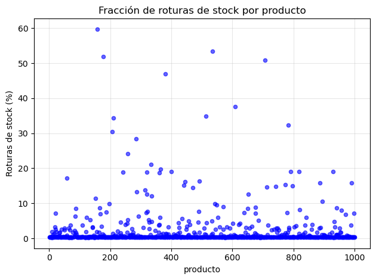

```python
# Roturas de stock por producto
roturas_stock_producto: pd.Series = dataset.groupby("producto", as_index=False).apply(
    lambda g: ((g["udsVenta"] == 0) & (g["udsStock"] == 0)).mean() * 100
)
roturas_stock_producto.columns = ["producto", "roturas_stock"]

ax: matplotlib.axes.Axes = roturas_stock_producto.plot(
    kind="scatter",
    x="producto",
    y="roturas_stock",
    alpha=0.6,
    color="blue"
)

ax.set_title("Fracción de roturas de stock por producto")
ax.set_xlabel("producto")
ax.set_ylabel("Roturas de stock (%)")

ax.grid(True, alpha=0.3)
ax.set_axisbelow(True)

plt.tight_layout()
plt.show()
```

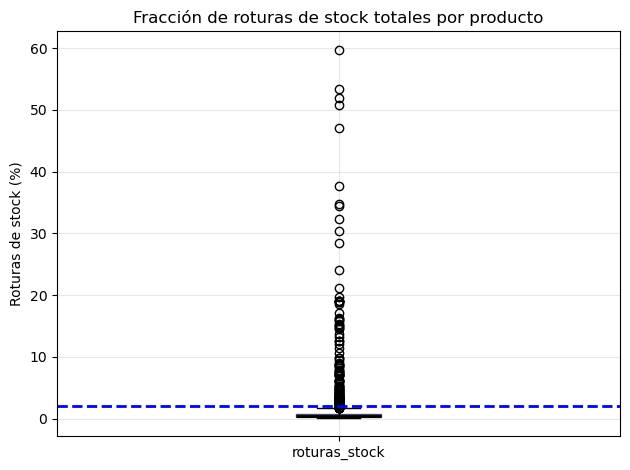

```python
# Boxplot de las roturas de stock por producto
roturas_stock_producto.boxplot(
    column="roturas_stock",
    patch_artist=True,
    boxprops=dict(facecolor="blue", alpha=0.6, color="black", linewidth=1),
    medianprops=dict(color="black", linewidth=2),
    whiskerprops=dict(color="black", linewidth=1),
    capprops=dict(color="black", linewidth=1)
)

plt.axhline(
    roturas_stock_producto["roturas_stock"].mean(),
    color="blue",
    linestyle="--",
    linewidth=2
)

plt.title("Fracción de roturas de stock totales por producto")
plt.ylabel("Roturas de stock (%)")

plt.grid(True, alpha=0.3)
plt.gca().set_axisbelow(True)

plt.tight_layout()
plt.show()
```

Las roturas de *stock*, a diferencia de la demanda baja, es un fenómeno minoritario en la mayoría de productos que se concentra en algunos casos muy específicos. Por lo tanto, la mayoría de ceros en *udsVenta* se corresponden a la demanda real, pero existe un reducido subconjunto donde esta demanda real se encuentra censurada por la falta de inventario, lo que introduce un sesgo en la variable objetivo y comporta su infraestimación en estos casos.

Así pues, se considera que la manera adecuada de proceder es mediante un proceso de imputación de los valores de la variable *udsVenta* que se corresponden con una rotura de *stock*. Este procedimiento debe realizarse con cautela, ya que se está imputando la propia variable objetivo, y la distribución de los *stockouts* no es homogénea en todos los productos como se muestra en el diagrama de la caja.

Para facilitar este proceso, se decide descartar del conjunto de datos aquellos productos cuyo porcentaje de *stockouts* supera el 10%, dado que únicamente representan aproximadamente un 4% del total de artículos. Esta decisión se fundamenta en que, en estos casos, la imputación de la variable objetivo implicaría reconstruir una parte significativa de la serie temporal, lo que podría introducir un sesgo considerable y distorsionar los patrones reales de la demanda. Por el contrario, para productos con una baja proporción de roturas, la imputación afecta únicamente a una fracción reducida de las observaciones, por lo que el impacto sobre la distribución de la variable objetivo es limitado. Asimismo, establecer un umbral inferior al 10% se considera excesivamente restrictivo, ya que conllevaría la eliminación de un número elevado de productos y, en consecuencia, una pérdida relevante de información en el conjunto

```python
# Productos con un porcentaje de rotura de stock superior al 10%
descartes: int = (
    roturas_stock_producto[roturas_stock_producto["roturas_stock"] > 10]
    .sort_values(by="roturas_stock", ascending=False)
    .shape[0]
)

print(
    f"Existen {descartes} productos con un porcentaje de rotura de stock superior al 10%, que representan un "
    f"{round(100 * (descartes / roturas_stock_producto.shape[0]), 2)}% del total de ítems"
)
```

```
Existen 39 productos con un porcentaje de rotura de stock superior al 10%, que representan un 4.53% del total de ítems
```

Dicho esto, el proceso de imputación que se seguirá es una interpolación lineal de la variable *udsVenta*, ya que permite estimar los valores faltantes a partir de la información local de la serie, preservando su estructura temporal. Esta metodología proporciona una aproximación razonable de la demanda sin introducir una complejidad innecesaria ni supuestos difíciles de justificar.

```python
# Se guarda la variable udsVenta original para compararla con ella misma tras la imputación
dataset["udsVenta_original"] = dataset["udsVenta"]
```

```python
# Interpolación de udsVenta en stockouts
dataset.loc[(dataset["udsVenta"] == 0) & (dataset["udsStock"] == 0), "udsVenta"] = np.nan

dataset["udsVenta"] = dataset.groupby("producto")["udsVenta"].transform(
    lambda g: g.interpolate(method="linear")
)
```

```python
# Función para hacer un gráfico comparativo de las ventas tras la imputación de udsVenta
def grafico_ventas(productos: List[int], df: pd.DataFrame) -> None:
    """Se crea un gráfico de las ventas de los productos antes y después del proceso de imputación

    Argumentos:
        productos: List[int] -> Lista con las IDs de los productos
        df: pd.DataFrame -> DataFrame de pandas con los datos de los productos

    Devuelve:
        None
    """
    fig, axs = plt.subplots(nrows=len(productos), ncols=1, figsize=(7, 20))

    for ax, producto in zip(axs, productos):
        dataframe_producto: pd.DataFrame = df[dataset["producto"] == producto]

        ax.plot(dataframe_producto["fecha"], dataframe_producto["udsVenta"], label="Ventas imputadas", color="red", alpha=0.6)
        ax.plot(dataframe_producto["fecha"], dataframe_producto["udsVenta_original"], label="Ventas originales", color="blue", alpha=0.5)

        ax.set_title(f"udsVentas del producto {producto} antes y después de la imputación")
        ax.set_xlabel("Fecha")
        ax.set_ylabel("Unidades")
        ax.legend(loc="upper left")
        ax.grid(True, alpha=0.3)
        ax.set_axisbelow(True)

    plt.tight_layout()
    plt.show()
```

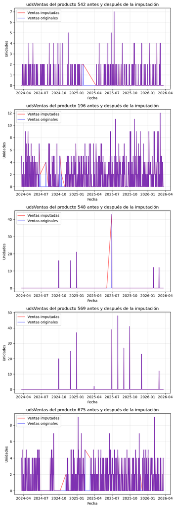

```python
# Comparación de udsVenta de los 5 productos con más porcentaje de stockout pero menor del 10%
productos: List[int] = (
    roturas_stock_producto[roturas_stock_producto["roturas_stock"] <= 10]
    .sort_values(by="roturas_stock", ascending=False)["producto"]
    .tolist()[:5]
)

grafico_ventas(productos, dataset)
```

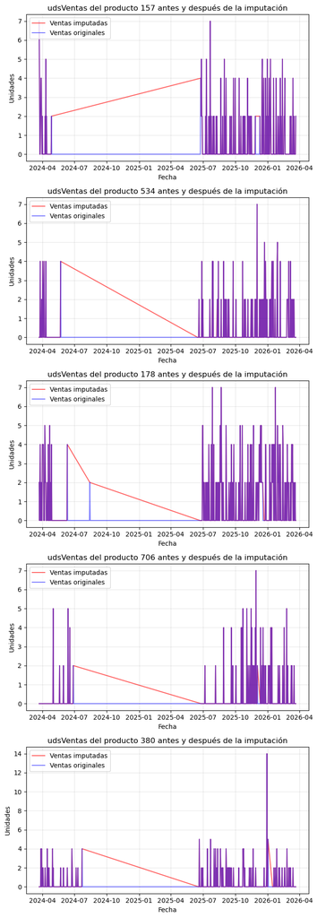

```python
# Comparación de udsVenta de los 5 productos con más porcentaje de stockout
productos: List[int] = (
    roturas_stock_producto
    .sort_values(by="roturas_stock", ascending=False)["producto"]
    .tolist()[:5]
)

grafico_ventas(productos, dataset)
```

```python
# Dataset con los productos con una proporción de stockout inferior al 10%
dataset: pd.DataFrame = dataset.merge(roturas_stock_producto, on="producto", how="left")
dataset_filtrado: pd.DataFrame = dataset[dataset["roturas_stock"] <= 10]
```

La validación visual de la imputación pone de manifiesto diferencias significativas en función de la proporción de las roturas de *stock*. En aquellos productos con la proporción de *stockout* más alta de los que tienen una fracción inferior al umbral del 10%, la imputación mediante interpolación permite reconstruir la demanda de forma coherente, respetando la dinámica de la serie temporal en intervalos de duración breve. Sin embargo, en aquellos productos con una elevada proporción de roturas de *stock*, la falta de información fiable provoca que la imputación genere patrones artificiales, como tendencias lineales prolongadas que no reflejan el comportamiento real de la demanda. Este resultado refuerza la necesidad de excluir del análisis aquellos productos con una proporción elevada de roturas de *stock*, dado que la imputación en estos casos introduce un sesgo significativo.

Por otro lado, cabe considerar los casos extremos donde el primer registro de la demanda histórica de un producto se corresponde a un *stockout*. En estas situaciones no se pueden imputar valores de forma lineal ya que no se dispone de registros anteriores para hacer la interpolación, por lo que siguen codificados como *NaN*. Asimismo, los días consiguientes a estas fechas también siguen conteniendo valores nulos hasta que ya no hay rotura de inventario.

```python
nulos_al_principio: pd.DataFrame = dataset_filtrado.groupby("producto", as_index=False).agg(
    nulos=("udsVenta", lambda g: g.isna().sum()),
    nulos_porcentaje=("udsVenta", lambda g: g.isna().mean() * 100)
)
nulos_al_principio: pd.DataFrame = (
    nulos_al_principio[nulos_al_principio["nulos"] > 0]
    .sort_values(by="nulos")
)

print(f"Hay {nulos_al_principio.shape[0]} productos con valores nulos en udsVenta al principio de la serie temporal")
```

```
Hay 26 productos con valores nulos en udsVenta al principio de la serie temporal
```

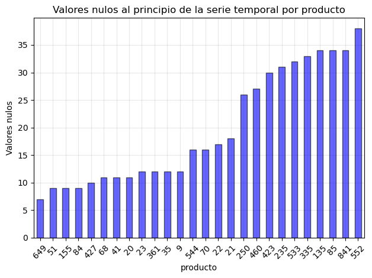

```python
# Valor absoluto de nulos
ax: matplotlib.axes.Axes = nulos_al_principio.plot(
    kind="bar",
    x="producto",
    y="nulos",
    color="blue",
    edgecolor="black",
    linewidth=1,
    alpha=0.6
)

ax.set_title(f"Valores nulos al principio de la serie temporal por producto")
ax.set_xlabel("producto")
ax.set_ylabel("Valores nulos")

ax.tick_params(axis="x", rotation=45)
ax.grid(True, alpha=0.3)
ax.set_axisbelow(True)
ax.get_legend().remove()

plt.tight_layout()
plt.show()
```

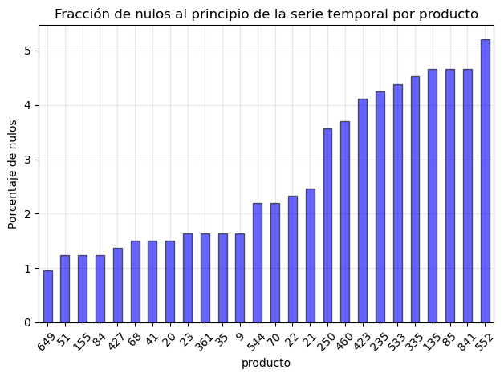

```python
# Porcentaje de nulos
ax: matplotlib.axes.Axes = nulos_al_principio.plot(
    kind="bar",
    x="producto",
    y="nulos_porcentaje",
    color="blue",
    edgecolor="black",
    linewidth=1,
    alpha=0.6
)

ax.set_title(f"Fracción de nulos al principio de la serie temporal por producto")
ax.set_xlabel("producto")
ax.set_ylabel("Porcentaje de nulos")
ax.tick_params(axis="x", rotation=45)
ax.grid(True, alpha=0.3)
ax.set_axisbelow(True)
ax.get_legend().remove()

plt.tight_layout()
plt.show()
```

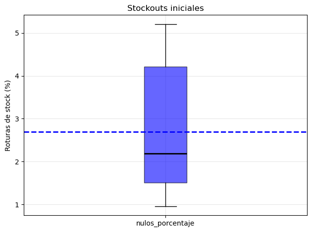

```python
# Boxplot del valor absoluto de valores nulos
ax: matplotlib.axes.Axes = nulos_al_principio["nulos_porcentaje"].plot(
    kind="box",
    patch_artist=True,
    boxprops=dict(facecolor="blue", alpha=0.6, color="black", linewidth=1),
    medianprops=dict(color="black", linewidth=2),
    whiskerprops=dict(color="black", linewidth=1),
    capprops=dict(color="black", linewidth=1)
)

plt.axhline(
    nulos_al_principio["nulos_porcentaje"].mean(),
    color="blue",
    linestyle="--",
    linewidth=2
)

ax.set_title("Stockouts iniciales")
ax.set_ylabel("Roturas de stock (%)")

ax.grid(True, alpha=0.3)
ax.set_axisbelow(True)

plt.tight_layout()
plt.show()
```

De la misma forma que con los *stockouts*, la distribución de valores nulos al principio de las series temporales no es uniforme, de manera que unos pocos productos contienen menos de un 2% de valores faltantes al inicio de la serie, y otros pocos entre un 2 y un 6%. Dado que estos valores deben ser imputados sin disponer de información previa en la serie, su tratamiento introduce un mayor grado de incertidumbre en comparación con la imputación de *udsVenta* cuando ocurren roturas de inventario en mitad de la serie temporal. Por otro lado, dado que las series analizadas presentan un horizonte amplio de dos años, el impacto de la imputación en los valores iniciales resulta limitado. En particular, los valores imputados representan una fracción reducida de la serie y se sitúan en el extremo inicial, alejados del horizonte de predicción, por lo que su influencia sobre los modelos de *forecasting* es marginal, ya que estos se apoyan principalmente en la dinámica más reciente de la serie temporal. Consecuentemente, se procede con la eliminación de estos valores nulos iniciales en todos los productos que los presenten. Asimismo, también podrían imputarse estos valores con un método de *backwards fill* que asigna el primer valor no nulo de la serie a los iniciales, pero en este caso se opta por no introducir un sesgo artificial, por pequeño que sea, porque representaría un segundo proceso de imputación en la variable objetivo.

```python
# Borrado de los registros con valores nulos al inicio de las series temporales
dataset_filtrado.dropna(inplace=True)
print(f"Tras el tratamiento de las roturas de stock, el dataset contiene {dataset_filtrado.shape[0]} registros")
```

```
Tras el tratamiento de las roturas de stock, el dataset contiene 599549 registros
```

# 3. Análisis de las variables

Tras haber evaluado la calidad de los datos y haber aplicado las operaciones pertinentes, se procede con el análisis de las variables del conjunto de datos. En particular, se pondrá el foco sobre aquellas que se empleen en los modelos de aprendizaje automático, por lo que *udsStock* no se analizará al detalle en un subapartado de dedicado.

## 3.1. Análisis de las variables auxiliares

En este apartado se analizan las variables del *dataset* que ayudan a explicar el comportamiento del atributo objetivo. Concretamente, se focaliza en las variables *producto*, *idSecuencia*, *isPromo*, *bolOpen*, *bolHoliday*, *diasEntrePedidos*, *diasLeadtime*, y *eurPrecioMedio*.

### 3.1.1. *producto*

El conjunto de datos inicialmente contaba con la información de 1000 productos distintos, y a medida que se ha avanzado en los apartados anteriores, algunos ítems se han ido descartando por su alto contenido en *stockouts*.

```python
# Productos descartados totales
descartes_totales: int = len(dataset["producto"].unique()) - len(dataset_filtrado["producto"].unique())
print(f"Tras revisar los stockouts, se han descartado un total de {descartes_totales} productos")
```

```
Tras revisar los stockouts, se han descartado un total de 39 productos
```

```python
# Total de productos en el dataset actual
productos: int = len(dataset_filtrado["producto"].unique())
print(f"El conjunto de datos contiene información de {productos} productos distintos")
```

```
El conjunto de datos contiene información de 822 productos distintos
```

```python
# Productos faltantes
TOTAL_PRODUCTOS: int = 1000
productos_faltantes: int = TOTAL_PRODUCTOS - productos - descartes_totales
print(f"Inicialmente, el dataset carecía de la demanda de {productos_faltantes} productos")
```

```
Inicialmente, el dataset carecía de la demanda de 139 productos
```

A pesar de haberse descartado 39 productos en las secciones anteriores, la suma de estos elementos con los actuales es inferior a 1000, lo que indica que el conjunto de datos inicialmente no contenía la demanda histórica de todos los productos. Esto sucede a pesar de que los archivos *DatosCicloAprovisionamiento.xlsx* y *DatosPrecioMedio.xlsx* contienen la información correpondiente de cada uno de los 1000 productos. Los datos de los ítems faltantes no se han adherido al dataset global dado que la operación que se ha empleado para unir las tablas de datos al principio era de tipo **LEFT JOIN**, situando a la izquierda la demanda histórica. No obstante, esta observación no tiene un impacto negativo de cara a la etapa de modelado, ya que simplemente algunos productos no se tendrán en cuenta en esa fase, lo cual debe tenerse en cuenta a la hora de tomar conclusiones.

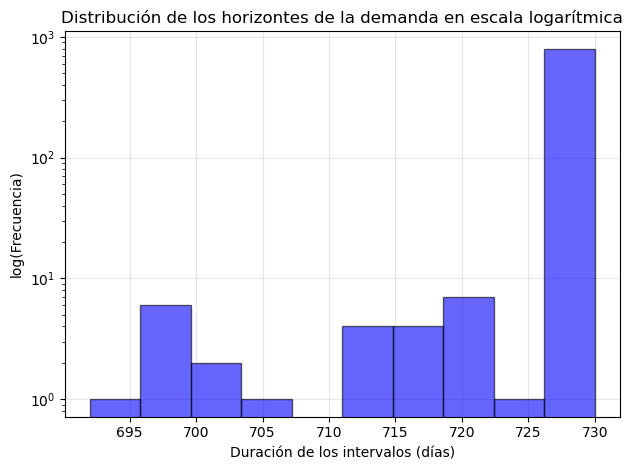

```python
# Distribución de los horizontes de la demanda
ax: matplotlib.axes.Axes = dataset_filtrado.groupby("producto").size().hist(
    log=True,
    bins=10,
    color="blue",
    edgecolor="black",
    linewidth=1,
    alpha=0.6
)

ax.set_title("Distribución de los horizontes de la demanda en escala logarítmica")
ax.set_xlabel("Duración de los intervalos (días)")
ax.set_ylabel("log(Frecuencia)")

ax.grid(True, alpha=0.3)
ax.set_axisbelow(True)

plt.tight_layout()
plt.show()
```

Por otro lado, el histograma logarítmico del horizonte temporal de cada producto sugiere que, inicialmente, prácticamente todos los productos contaban con el mismo número de fechas en su demanda histórica. Sin embargo, tras haber eliminado los *stockouts* del comienzo de las series temporales de algunos productos en el apartado Roturas de *stock*, esto ha dado lugar a una distribución de la duración de los intervalos de la demanda donde, como máximo, las series de algunos productos contienen menos de 700 días. No obstante, en estos casos se sigue disponiendo de una cantidad adecuada de información para entrenar los modelos, y no se considera que esta heterogeneidad sea suficiente como para tener una influencia significativa en el rendimiento de los modelos en estos productos concretos. Por lo tanto, esta observación refuerza la decisión tomada en la sección Roturas de *stock*, donde se ha considerado que el borrado de los registros de roturas de inventario al principio de las series temporales no introduciría un sesgo importante debido a la amplitud de los horizontes temporales.

### 3.1.2. *idSecuencia*

Este atributo equivale a las fechas de las que se dispone la demanda de los ítems de la empresa. Entonces, uno de los supuestos que se hace al trabajar con estos datos es que, para cada producto, se debería contar con la demanda a nivel de día, sin huecos temporales entre medio.

```python
# Función de agregación personalizada para comprobar el espaciado en el tiempo de las fechas
def diferencia_entre_dias(grupo: pd.Series) -> bool:
    """Comprueba si una secuencia de fechas está espaciada en el tiempo por un día en todos
    sus registros

    Argumentos:
        grupo: pd.Series -> Grupo al que aplicar la función tras hacer un groupby()

    Devuelve:
        bool -> Si las fechas del grupo están todas espaciadas un día
    """
    secuencia: pd.Series = grupo.sort_values()
    return (secuencia.diff().dropna().dt.days == 1).all()
```

```python
# Comprobación de la granularidad diaria de los datos por producto
intervalos: pd.DataFrame = dataset_filtrado.groupby("producto", as_index=False).agg(
    fecha_inicio=("idSecuencia", "min"),
    fecha_final=("idSecuencia", "max"),
    secuencia_correcta=("fecha", diferencia_entre_dias)
)

if intervalos["secuencia_correcta"].all():
    print("Todas las fechas de todos los productos están espaciadas un día en el calendario")
```

```
Todas las fechas de todos los productos están espaciadas un día en el calendario
```

Por otra banda, una de las observaciones que ya se ha hecho durante el presente análisis exploratorio es que el horizonte temporal de la demanda abraca apróximadamente dos años para todos los ítems. Asimismo, el hecho que todas las fechas estén espaciadas un día indica que todas las series temporales terminan el mismo día en el conjunto de datos con el que es está trabajando. Sin embargo, la eliminación de algunos registros iniciales en Roturas de *stock* ha provocado que no todas las series temporales empiecen el mismo día.

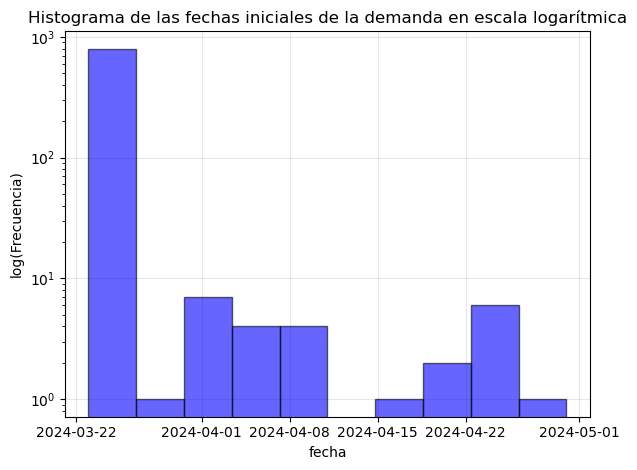

```python
# Histograma de las fechas iniciales de las series temporales
ax: matplotlib.axes.Axes = dataset_filtrado.groupby("producto")["fecha"].agg("min").hist(
    log=True,
    bins=10,
    color="blue",
    edgecolor="black",
    linewidth=1,
    alpha=0.6
)

ax.set_title("Histograma de las fechas iniciales de la demanda en escala logarítmica")
ax.set_xlabel("fecha")
ax.set_ylabel("log(Frecuencia)")

ax.grid(True, alpha=0.3)
ax.set_axisbelow(True)

plt.tight_layout()
plt.show()
```

La distribución logarítmica de las fechas iniciales de la demanda sitúa buena parte de estos factores cerca del comienzo de la mayoría de las series temporales del *dataset*, siendo este el día 2024-03-22. Asimismo, existe un reducido subconjunto de productos con una inicio ligeramente más alejado, situado como máximo a poco más de un mes del día 2024-03-22, el cual se corresponde con aquellos productos que presentaban una secuencia de *stockouts* iniciales más duradera. Nótese que se ha usado la variable *fecha* en el histograma, pero esta es equivalente a *idSecuencia* y más sencilla de interpretar.

Por último, se añaden al conjunto de datos una serie de variables adicionales relacionadas con la fecha que pueden ser útiles más adelante para relacionar las ventas con patrones temporales de carácter semanal o mensual, siendo estas los días de la semana y los meses.

```python
# Días de la semana
traducciones: Dict[str, str] = {
    "Monday": "Lunes",
    "Tuesday": "Martes",
    "Wednesday": "Miércoles",
    "Thursday": "Jueves",
    "Friday": "Viernes",
    "Saturday": "Sábado",
    "Sunday": "Domingo"
}

dataset_filtrado["dia_semana_str"] = dataset_filtrado["fecha"].dt.day_name()
dataset_filtrado.replace({"dia_semana_str": traducciones}, inplace=True)
dataset_filtrado["dia_semana_str"] = pd.Categorical(
    dataset_filtrado["dia_semana_str"],
    categories=traducciones.values(),
    ordered=True
)

dataset_filtrado["dia_semana_int"] = dataset_filtrado["fecha"].dt.weekday
```

```python
# Meses
dataset_filtrado["mes_int"] = dataset_filtrado["fecha"].dt.month
```

### 3.1.3. *idPromo*

La aplicación de promociones generalmente es una buena estrategia para aumentar las ventas de ciertos ítems. Consecuentemente, es un factor que juega un papel importante en la predicción de la demanda. Este atributo es de tipo *booleano* a pesar de que se codifique como un entero, y debe analizarse tanto de forma global como a nivel de producto.

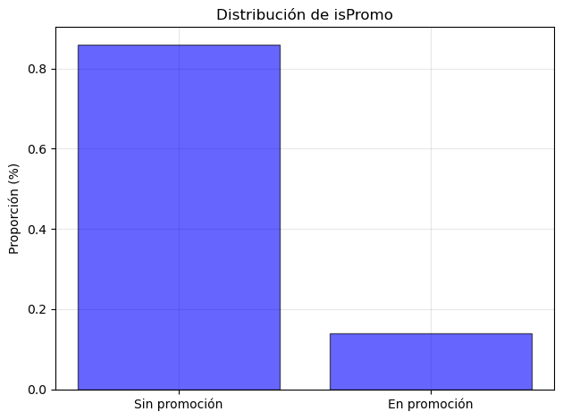

```python
# Análisis global de isPromo
proporcion_ispromo: List[float] = [
    round(dataset_filtrado[dataset_filtrado["isPromo"] == 0].shape[0] / dataset_filtrado.shape[0], 2),
    round(dataset_filtrado[dataset_filtrado["isPromo"] == 1].shape[0] / dataset_filtrado.shape[0], 2),
]

plt.bar(
    ["Sin promoción", "En promoción"],
    proporcion_ispromo,
    color="blue",
    edgecolor="black",
    linewidth=1,
    alpha=0.6
)

plt.title("Distribución de isPromo")
plt.ylabel("Proporción (%)")

plt.grid(True, alpha=0.3)
plt.gca().set_axisbelow(True)

plt.tight_layout()
plt.show()
```

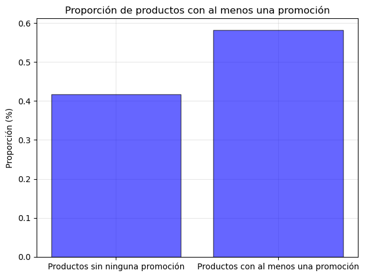

```python
# Productos sin promociones
promociones_analisis: pd.DataFrame = dataset_filtrado.groupby("producto", as_index=False)["isPromo"].agg("mean")
promociones_analisis.loc[promociones_analisis["isPromo"] > 0, "isPromo"] = 1

plt.bar(
    ["Productos sin ninguna promoción", "Productos con al menos una promoción"], [
        promociones_analisis[promociones_analisis["isPromo"] == 0].shape[0] / promociones_analisis.shape[0],
        promociones_analisis[promociones_analisis["isPromo"] == 1].shape[0] / promociones_analisis.shape[0]
    ], color="blue",
    edgecolor="black",
    linewidth=1,
    alpha=0.6
)

plt.title("Proporción de productos con al menos una promoción")
plt.ylabel("Proporción (%)")

plt.grid(True, alpha=0.3)
plt.gca().set_axisbelow(True)

plt.tight_layout()
plt.show()
```

El gráfico *Distribución de isPromo* denota que, durante la gran mayoría de días del intervalo de las demandas históricas, a los productos no se les aplican promociones, siendo estas situaciones casos excepcionales. Esta observación se ve reforzada por el hecho que a prácticamente la mitad de los productos no se les aplican promociones en ningún momento de sus historial de la demanda. La aplicación de promociones pues, es un caso aislado que puede deberse a distintos factores, como períodos vacacionales donde la demanda suele crecer y se busca aumentar las ventas mediante promociones, liquidaciones, o simplemente se desea aumantar las ventas de los ítems por cualquier otra razón. No obstante, esto es a nivel general en el *dataset*, pero hace falta realizar el análisis también a nivel de producto.

```python
# Análisis por producto de isPromo
analisis_promo: pd.DataFrame = dataset_filtrado.groupby("producto").agg(
    pct_promo=("isPromo", "mean"),
    promedio_ventas=("udsVenta", "mean"),
    promedio_ventas_promo=("udsVenta", lambda g: g[dataset_filtrado.loc[g.index, "isPromo"] == 1].mean()),
    promedio_ventas_no_promo=("udsVenta", lambda g: g[dataset_filtrado.loc[g.index, "isPromo"] == 0].mean())
).reset_index()
```

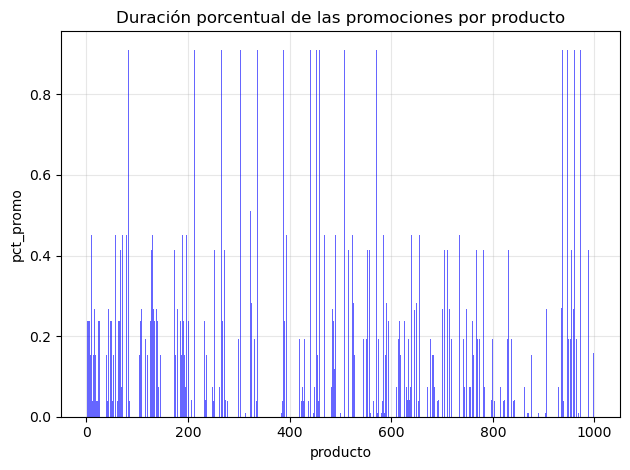

```python
# Porcentajes de promoción en el intervalo temporal de cada producto
plt.bar(
    analisis_promo["producto"],
    analisis_promo["pct_promo"],
    color="blue",
    alpha=0.6
)

plt.title("Duración porcentual de las promociones por producto")
plt.xlabel("producto")
plt.ylabel("pct_promo")

plt.grid(True, alpha=0.3)
plt.gca().set_axisbelow(True)

plt.tight_layout()
plt.show()
```

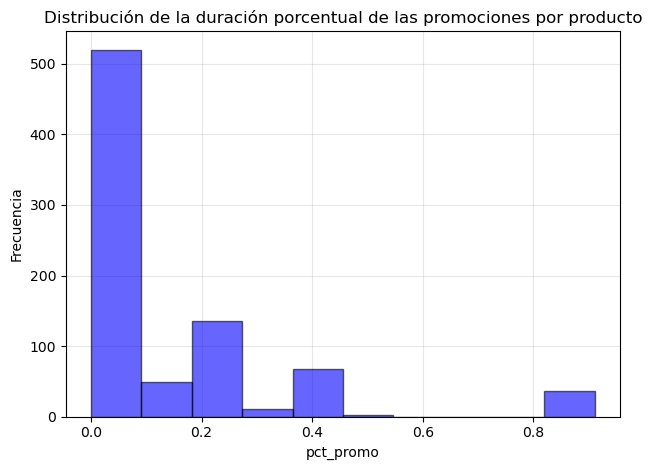

```python
# Distribución de los porcentajes de promoción en la duración de los intervalos de la demanda
ax: matplotlib.axes.Axes = analisis_promo["pct_promo"].hist(
    color="blue",
    edgecolor="black",
    linewidth=1,
    alpha=0.6
)

ax.set_title("Distribución de la duración porcentual de las promociones por producto")
ax.set_xlabel("pct_promo")
ax.set_ylabel("Frecuencia")

ax.grid(True, alpha=0.3)
ax.set_axisbelow(True)

plt.tight_layout()
plt.show()
```

```python
# Productos con más de un 80% de tiempo promocional
print(
    f"Hay un total de {analisis_promo[analisis_promo["pct_promo"] >= 0.8].shape[0]} productos con "
    "más de un 80% de tiempo promocional"
)
print(
    f"Algunos de estos productos son los de IDs {
        ", ".join([str(n )for n in analisis_promo[analisis_promo["pct_promo"] >= 0.8].sort_values(by="pct_promo")["producto"].tolist()[:5]])
    }"
)
```

```
Hay un total de 37 productos con más de un 80% de tiempo promocional
Algunos de estos productos son los de IDs 29, 31, 33, 34, 72
```

De la misma manera que con el conjunto de datos a nivel general, la mayoría de productos están sujetos a períodos promocionales muy breves, mientras que un reducido subconjunto de ítems cuentan con promociones muy duraderas, hasta el punto que en varios casos abarcan más del 80% del intervalo de demanda del que se dispone. Esta última observación puede deberse a varios factores como los mencionados anteriormente.

Por otro lado, para profundizar más en el análisis a nivel de producto, se añade la variable *mejora_promo*, que es la diferencia entre *promedio_ventas_promo* y *promedio_ventas_no_promo*, la cual indica si una promoción resulta en más ventas de un producto concreto.

```python
analisis_promo["mejora_promo"] = analisis_promo["promedio_ventas_promo"] - analisis_promo["promedio_ventas_no_promo"]
```

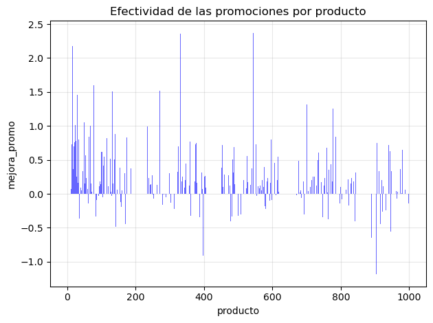

```python
# Efectividad de las promociones en las ventas
plt.bar(
    analisis_promo["producto"],
    analisis_promo["mejora_promo"],
    color="blue",
    alpha=0.6
)

plt.title("Efectividad de las promociones por producto")
plt.xlabel("producto")
plt.ylabel("mejora_promo")

plt.grid(True, alpha=0.3)
plt.gca().set_axisbelow(True)

plt.tight_layout()
plt.show()
```

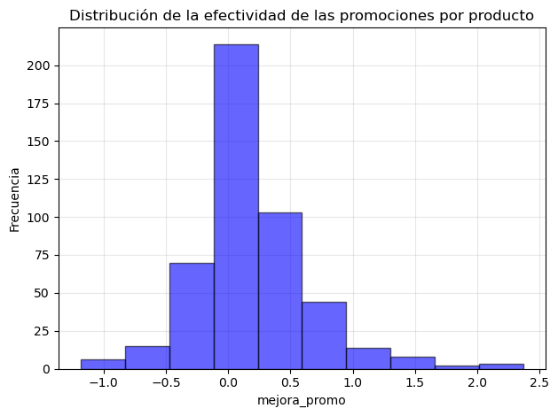

```python
# Distribución de la efectividad de las promociones en las ventass
ax: matplotlib.axes.Axes = analisis_promo["mejora_promo"].hist(
    color="blue",
    edgecolor="black",
    linewidth=1,
    alpha=0.6
)

ax.set_title("Distribución de la efectividad de las promociones por producto")
ax.set_xlabel("mejora_promo")
ax.set_ylabel("Frecuencia")

ax.grid(True, alpha=0.3)
ax.set_axisbelow(True)

plt.tight_layout()
plt.show()
```

```python
# IDs de los ítems cuyas ventas mejoran más con las promociones, e IDs de los que las
# ventas empeoran
productos_mejora: List[int] = analisis_promo.sort_values(by="mejora_promo", ascending=False)["producto"].tolist()[:5]
productos_empeora: List[int] = analisis_promo.sort_values(by="mejora_promo")["producto"].tolist()[:5]

print(f"Las ventas de los productos {", ".join([str(n) for n in productos_mejora])} mejoran significativamente cuando se les aplica una promoción")
print(f"Las ventas de los ítems {", ".join([str(n) for n in productos_empeora])} empeoran de forma considerable cuando se les aplica una promoción")
```

```
Las ventas de los productos 544, 331, 16, 216, 65 mejoran significativamente cuando se les aplica una promoción
Las ventas de los ítems 904, 479, 447, 423, 397 empeoran de forma considerable cuando se les aplica una promoción
```

Gracias a la variable compuesta *mejora_promo*, se puede observar cómo la mayoría de productos permanecen prácticamente invariantes cuando se les aplica una promoción. Sin embargo, también se aprecia un mayor volumen de productos cuyas ventas mejoran cuando están sujetos a promociones que en el caso contrario, es decir, cuyas ventas empeoran. Esto es de esperar, ya que es un comportamiento intuitivo cuando un producto forma parte de una promoción, pero también cabe destacar que hay una cantidad considerable cuyas ventas disminuyen cuando se promocionan. Una posible explicación de este hecho es que la aplicación de una promoción a un cierto conjunto de ítems puede generar un efecto de competencia interna entre productos, de manera que el incremento de ventas en algunos artículos se produce a costa de otros también promocionados. Este fenómeno puede estar motivado por la limitada atención del consumidor o por restricciones presupuestarias, que llevan al cliente a priorizar unos productos frente a otros dentro del mismo contexto promocional. Asimismo, cabe recordar que la empresa en cuestión distribuye productos para el automóvil, lo cual introduce una gran heterogeneidad en la naturaleza de la demanda. Estos ítems pueden abarcar desde productos muy específicos, cuya compra está condicionada por necesidades puntuales y poco frecuentes como averías o sustituciones concretas, hasta productos más genéricos o impulsivos, como ambientadores o accesorios. En este contexto, es más probable que los efectos negativos de la promoción se produzcan en aquellos productos con mayor grado de sustituibilidad, donde el consumidor dispone de múltiples alternativas.

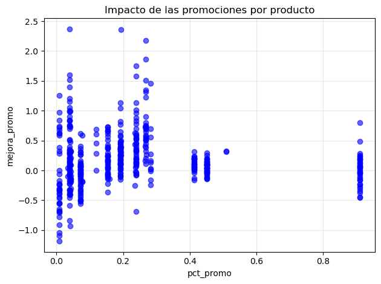

```python
# Impacto de las promociones
plt.scatter(
    analisis_promo["pct_promo"],
    analisis_promo["mejora_promo"],
    color="blue",
    alpha=0.6
)

plt.title("Impacto de las promociones por producto")
plt.xlabel("pct_promo")
plt.ylabel("mejora_promo")

plt.grid(True, alpha=0.3)
plt.gca().set_axisbelow(True)

plt.tight_layout()
plt.show()
```

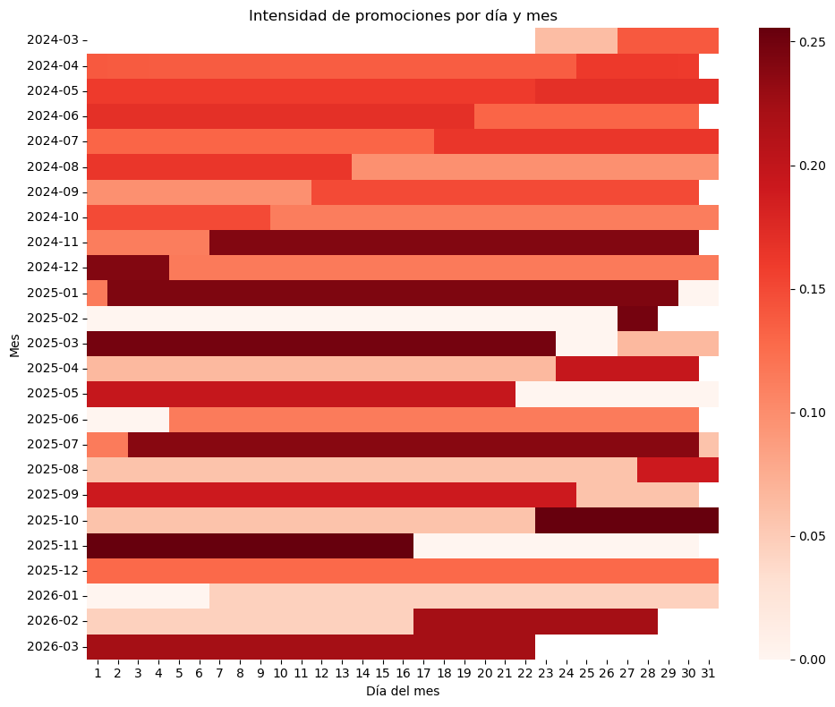

```python
# Intensidad de las promociones por fecha
dataset_filtrado["año_mes"] = dataset_filtrado["fecha"].dt.to_period("M")
dataset_filtrado["dia"] = dataset_filtrado["fecha"].dt.day

datos_heatmap: pd.DataFrame = dataset_filtrado.groupby(["año_mes", "dia"])["isPromo"].mean().unstack()

plt.figure(figsize=(10, 8))

sns.heatmap(datos_heatmap, cmap="Reds")

plt.title("Intensidad de promociones por día y mes")
plt.xlabel("Día del mes")
plt.ylabel("Mes")

plt.tight_layout()
plt.show()
```

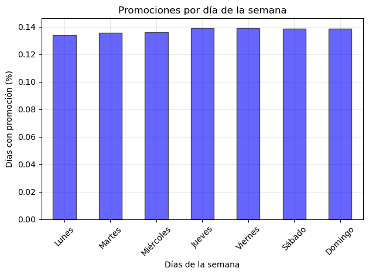

```python
# Promociones por día de la semana
promo_semanal: pd.DataFrame = dataset_filtrado.groupby("dia_semana_str")["isPromo"].mean()

promo_semanal.plot(
    kind="bar",
    color="blue",
    edgecolor="black",
    linewidth=1,
    alpha=0.6
)

plt.title("Promociones por día de la semana")
plt.xlabel("Días de la semana")
plt.tick_params(axis="x", rotation=45)
plt.ylabel("Días con promoción (%)")

plt.grid(True, alpha=0.3)
plt.gca().set_axisbelow(True)

plt.tight_layout()
plt.show()
```

La intensidad de promociones a lo largo del calendario muestra que, si bien no existe una estacionalidad extremadamente marcada, sí se aprecian ciertos periodos con mayor concentración de campañas promocionales. En particular, algunos meses presentan niveles más elevados de intensidad, lo que sugiere la existencia de estrategias comerciales puntuales más que un patrón estrictamente estacional. Este comportamiento es coherente con la naturaleza de la empresa, dedicada a la distribución de productos para el automóvil. A diferencia de otros sectores más sensibles a la estacionalidad, como la moda o el turismo, la demanda de muchos de estos productos está ligada a necesidades funcionales o imprevistas , lo que reduce la dependencia directa de la época del año. No obstante, sí pueden identificarse ciertos incrementos en la actividad promocional en momentos concretos, posiblemente asociados a campañas comerciales específicas o a productos de carácter más discrecional, como accesorios o elementos decorativos del vehículo. En estos casos, la estacionalidad puede tener un mayor peso, especialmente en periodos como verano y Navidad o fechas cercanas a campañas como el *black friday* en noviembre.

Asimismo, el análisis de la distribución de promociones a lo largo de la semana muestra que su intensidad se mantiene prácticamente constante entre los distintos días, sin apreciarse diferencias significativas entre días laborables y fines de semana. Este resultado refuerza la idea de que las promociones en este contexto no están orientadas a maximizar el impacto en momentos específicos de consumo, sino que responden a estrategias de mayor duración en el tiempo.

Así pues, en conjunto, el patrón observado sugiere que las promociones en este sector responden en mayor medida a decisiones estratégicas de la empresa que a una estacionalidad estricta de la demanda, aunque ciertos segmentos de producto sí pueden presentar comportamientos más sensibles al calendario.

### 3.1.4. *bolOpen*

El estudio de la variable *bolOpen* resulta interesante en este contexto, ya que los horarios de apertura de una tienda de productos del automóvil pueden diferir significativamente respecto a otro tipo de comercios. Esto se debe a que algunos ítems que de los establecimientos de la empresa presente pueden ser de alta urgencia, lo que posiblemente provoque un horario de apertura más amplio a lo largo de la semana.

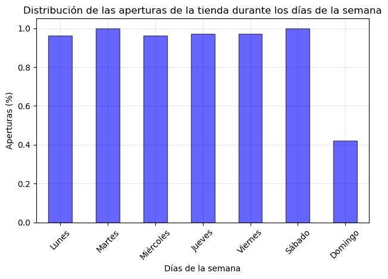

```python
# Distribución de aperturas de la tienda durante los días de la semana
apertura_semanal: pd.DataFrame = dataset_filtrado.groupby("dia_semana_str")["bolOpen"].mean()

apertura_semanal.plot(
    kind="bar",
    color="blue",
    edgecolor="black",
    linewidth=1,
    alpha=0.6
)

plt.title("Distribución de las aperturas de la tienda durante los días de la semana")
plt.xlabel("Días de la semana")
plt.tick_params(axis="x", rotation=45)
plt.ylabel("Aperturas (%)")

plt.grid(True, alpha=0.3)
plt.gca().set_axisbelow(True)

plt.tight_layout()
plt.show()
```

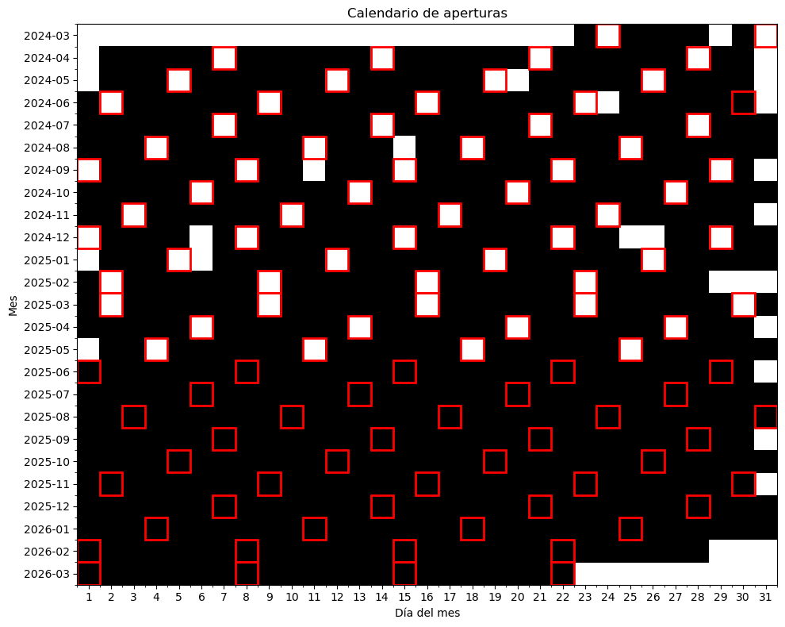

```python
# Matriz de aperturas
calendario_aperturas: pd.DataFrame = dataset_filtrado.groupby("idSecuencia").agg({
    "año_mes": "first",
    "dia": "first",
    "bolOpen": "first",
    "dia_semana_str": "first",
    "bolHoliday": "first"
})

datos: pd.DataFrame = calendario_aperturas.pivot(
    index="año_mes",
    columns="dia",
    values="bolOpen"
).fillna(0)

# Gráfico del calendario de aperturas de la tienda
fig, ax = plt.subplots(figsize=(10, 8))
cmap: ListedColormap = ListedColormap(["white", "black"])

im = ax.imshow(datos.values, cmap=cmap, aspect="auto")

ax.set_xticks(np.arange(datos.shape[1]))
ax.set_yticks(np.arange(datos.shape[0]))

ax.set_xticklabels(datos.columns)
ax.set_yticklabels(datos.index)

ax.set_xlabel("Día del mes")
ax.set_ylabel("Mes")
ax.set_title("Calendario de aperturas")

ax.set_xticks(np.arange(-.5, datos.shape[1], 1), minor=True)
ax.set_yticks(np.arange(-.5, datos.shape[0], 1), minor=True)

# Se marcan los domingos en rojo
domingos: pd.DataFrame = calendario_aperturas[calendario_aperturas["dia_semana_str"] == "Domingo"]

for _, row in domingos.iterrows():
    fila: int = list(datos.index).index(row["año_mes"])
    col: int = list(datos.columns).index(row["dia"])

    ax.add_patch(plt.Rectangle(
        (col - 0.5, fila - 0.5),
        1, 1,
        fill=False,
        edgecolor="red",
        linewidth=2
    ))

plt.tight_layout()
plt.show()
```

La distribución de aperturas a lo largo de los días de la semana del establecimiento indica que la tienda, generalmente, sigue un horario de lunes a sábado, ofreciendo sus servicios durante parte del fin de semana. Además, el gráfico demuestra que el local también ha abierto sus puertas prácticamente la mitad de todos los domingos de los intervalos de la demanda. Esta observación se complementa con el calendario de aperturas de la tienda, donde se aprecia que el establecimiento permaneció cerrado durante aproximadamente todos los domingos del año 2024 hasta mitades del año 2025, pero a partir de este punto el local abrió sus puertas a diario prácticamente. Además, también resulta interesante comprobar si la tienda también permaneció abierta en este intervalo de tiempo durante las festividades, aunque esto se realizará en el apartado *bolHoliday*. Volviendo a la cuestión, esta observación puede deberse a una decisión empresarial para aumentar las ventas, o a una nueva estrategia donde se hayan repartido las horas de apertura semanales de tal forma que el local pueda abrir los domingos sin aumentar el volumen total de tiempo de apertura semanal.

### 3.1.5. *bolHoliday*

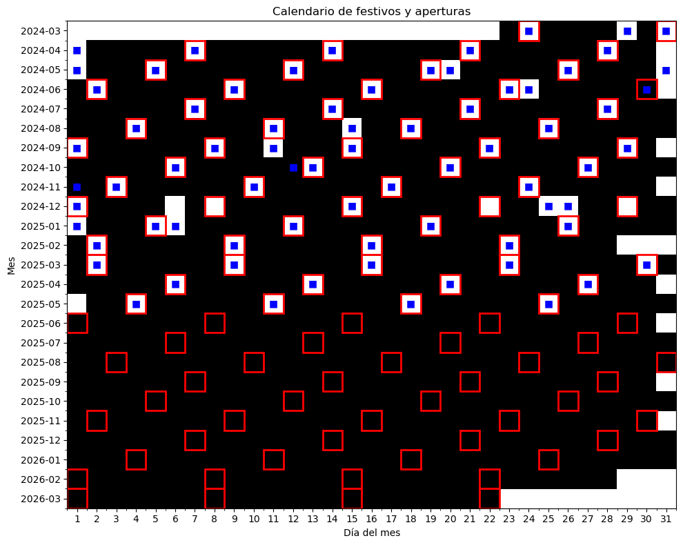

```python
# Calendario de festivos y aperturas de la tienda
fig, ax = plt.subplots(figsize=(10, 8))
cmap: ListedColormap = ListedColormap(["white", "black"])

im = ax.imshow(datos.values, cmap=cmap, aspect="auto")

ax.set_xticks(np.arange(datos.shape[1]))
ax.set_yticks(np.arange(datos.shape[0]))

ax.set_xticklabels(datos.columns)
ax.set_yticklabels(datos.index)

ax.set_xlabel("Día del mes")
ax.set_ylabel("Mes")
ax.set_title("Calendario de festivos y aperturas")

ax.set_xticks(np.arange(-.5, datos.shape[1], 1), minor=True)
ax.set_yticks(np.arange(-.5, datos.shape[0], 1), minor=True)

# Se marcan los domingos en rojo
domingos: pd.DataFrame = calendario_aperturas[calendario_aperturas["dia_semana_str"] == "Domingo"]

for _, row in domingos.iterrows():
    fila: int = list(datos.index).index(row["año_mes"])
    col: int = list(datos.columns).index(row["dia"])

    ax.add_patch(plt.Rectangle(
        (col - 0.5, fila - 0.5),
        1, 1,
        fill=False,
        edgecolor="red",
        linewidth=2
    ))

# Se añaden las festividades con un cuadrado azul
festividades: pd.DataFrame = calendario_aperturas[calendario_aperturas["bolHoliday"] == 1]

for _, row in festividades.iterrows():
    fila: int = list(datos.index).index(row["año_mes"])
    col: int = list(datos.columns).index(row["dia"])

    ax.text(
        col, fila,
        "■",
        ha="center",
        va="center",
        color="blue",
        fontsize=10
    )

plt.tight_layout()
plt.show()
```

La distribución de los días festivos observada en el *dataset* es coherente con calendarios laborales catalanes, donde los días de la diada catalana, el lunes de Pascua y San Esteban se consideran días festivos donde la empresa no abre. Por otro lado, en el apartado anterior se observó que el local empezó a abrir cada día a partir de mitad del año 2025, lo que se consideró como una posible estrategia empresarial. No obstante, la adición de *bolHoliday* en el calendario revela inconsistencias a partir de mediados de este mismo período, donde también desaparecen los días festivos. Este comportamiento resulta irreal desde un punto de vista operativo, lo que sugiere la existencia de datos incompletos o errores en el registro. Consecuentemente, se opta por reconstruir la información relacionada tanto con las festividades como con las aperturas, hecho que permite disponer de variables coherentes a lo largo de todo el horizonte temporal, evitando la pérdida de datos y reduciendo el impacto de posibles errores en el *dataset* original.